# RTI Data Science Exercise

## RTI Analytics Exercise

### Step 1. Read in and Stage data for analysis

```r
library(tidyverse)

# read in data
records <- read_csv('C:/Users/Will/Documents/MSA/jobs/rti_challenge/data-scientist-exercise01/data/flat_records.csv',
                    col_names = F)

# add column names
names(records) <- c('id', 'age', 'workclass_id', 'education_level_id', #records
                    'education_num', 'marital_status_id',  #records
                    'occupation_id','relationship_id', 'race_id', #records
                    'sex_id', 'capital_gain', 'capital_loss',   #records
                    'hours_week', 'country_id', 'over_50k', #records
                    'country_id2','country', #countries
                    'education_level_id2', 'education_level', #education_levels
                    'marital_status_id2', 'marital_status', #marital_statuses
                    'occupation_id2','occupation', #occupations
                    'race_id2', 'race', #races
                    'relationship_id2', 'relationship', #relationships
                    'sex_id2', 'sex', #sexes
                    'workclass_id2', 'workclass') #workclasses

# replace all ? with NA
records[records == '?'] <- NA

# Remove the id columns, convert character columns to factor,
# and re-order the education levels
records %>%
  select(-contains('id')) %>%
  mutate_each(funs(factor(.)), -c(age:hours_week)) %>%
  mutate(education_level = factor(education_level,
                                   levels =  c("Preschool", "1st-4th", "5th-6th",
                                                "7th-8th", "9th", "10th", "11th",
                                                "12th", "HS-grad", "Some-college",
                                                "Assoc-voc",  "Assoc-acdm", "Bachelors",
                                                "Masters","Prof-school", "Doctorate")))  -> records
```

```r
dim(records)
```

```
[1] 48842    14
```

### Step 2: Exploratory Analysis

**Summary**

The Exploratory Analysis revealed some interesting insights about the data:

1. The survey is most likely filled out by the men of the household: This is evident by the variables gender, and relationship.
2. There are a few variables that have some hard cutoff values including age, hours worked, and capital gain.
3. There are people who report they have never worked, yet they report on average close to 25 hours a week.

| age | education_num | capital_gain | capital_loss | hours_week | over_50k | country | education_level | marital_status | occupation | race | relationship | sex | workclass |
| --- | --- | --- | --- | --- | --- | --- | --- | --- | --- | --- | --- | --- | --- |
| 39 | 13 | 2174 | 0 | 40 | 0 | United-States | Bachelors | Never-married | Adm-clerical | White | Not-in-family | Male | State-gov |
| 50 | 13 | 0 | 0 | 13 | 0 | United-States | Bachelors | Married-civ-spouse | Exec-managerial | White | Husband | Male | Self-emp-not-inc |
| 38 | 9 | 0 | 0 | 40 | 0 | United-States | HS-grad | Divorced | Handlers-cleaners | White | Not-in-family | Male | Private |
| 53 | 7 | 0 | 0 | 40 | 0 | United-States | 11th | Married-civ-spouse | Handlers-cleaners | Black | Husband | Male | Private |
| 28 | 13 | 0 | 0 | 40 | 0 | Cuba | Bachelors | Married-civ-spouse | Prof-specialty | Black | Wife | Female | Private |
| 37 | 14 | 0 | 0 | 40 | 0 | United-States | Masters | Married-civ-spouse | Exec-managerial | White | Wife | Female | Private |

| age | education_num | capital_gain | capital_loss | hours_week | over_50k | country | education_level | marital_status | occupation | race | relationship | sex | workclass |
| --- | --- | --- | --- | --- | --- | --- | --- | --- | --- | --- | --- | --- | --- |
| 33 | 13 | 0 | 0 | 40 | 0 | United-States | Bachelors | Never-married | Prof-specialty | White | Own-child | Male | Private |
| 39 | 13 | 0 | 0 | 36 | 0 | United-States | Bachelors | Divorced | Prof-specialty | White | Not-in-family | Female | Private |
| 64 | 9 | 0 | 0 | 40 | 0 | United-States | HS-grad | Widowed | NA | Black | Other-relative | Male | NA |
| 38 | 13 | 0 | 0 | 50 | 0 | United-States | Bachelors | Married-civ-spouse | Prof-specialty | White | Husband | Male | Private |
| 44 | 13 | 5455 | 0 | 40 | 0 | United-States | Bachelors | Divorced | Adm-clerical | Asian-Pac-Islander | Own-child | Male | Private |
| 35 | 13 | 0 | 0 | 60 | 1 | United-States | Bachelors | Married-civ-spouse | Exec-managerial | White | Husband | Male | Self-emp-inc |

```r
summary(records)
```

```
      age        education_num    capital_gain    capital_loss      hours_week    over_50k
 Min.   :17.00   Min.   : 1.00   Min.   :    0   Min.   :   0.0   Min.   : 1.00   0:37155
 1st Qu.:28.00   1st Qu.: 9.00   1st Qu.:    0   1st Qu.:   0.0   1st Qu.:40.00   1:11687
 Median :37.00   Median :10.00   Median :    0   Median :   0.0   Median :40.00
 Mean   :38.64   Mean   :10.08   Mean   : 1079   Mean   :  87.5   Mean   :40.42
 3rd Qu.:48.00   3rd Qu.:12.00   3rd Qu.:    0   3rd Qu.:   0.0   3rd Qu.:45.00
 Max.   :90.00   Max.   :16.00   Max.   :99999   Max.   :4356.0   Max.   :99.00

          country          education_level                marital_status            occupation
 United-States:43832   HS-grad     :15784   Divorced             : 6633   Prof-specialty : 6172
 Mexico       :  951   Some-college:10878   Married-AF-spouse    :   37   Craft-repair   : 6112
 Philippines  :  295   Bachelors   : 8025   Married-civ-spouse   :22379   Exec-managerial: 6086
 Germany      :  206   Masters     : 2657   Married-spouse-absent:  628   Adm-clerical   : 5611
 Puerto-Rico  :  184   Assoc-voc   : 2061   Never-married        :16117   Sales          : 5504
 (Other)      : 2517   11th        : 1812   Separated            : 1530   (Other)        :16548
 NA's         :  857   (Other)     : 7625   Widowed              : 1518   NA's           : 2809
                 race               relationship       sex                   workclass
 Amer-Indian-Eskimo:  470   Husband       :19716   Female:16192   Private         :33906
 Asian-Pac-Islander: 1519   Not-in-family :12583   Male  :32650   Self-emp-not-inc: 3862
 Black             : 4685   Other-relative: 1506                  Local-gov       : 3136
 Other             :  406   Own-child     : 7581                  State-gov       : 1981
 White             :41762   Unmarried     : 5125                  Self-emp-inc    : 1695
                            Wife          : 2331                  (Other)         : 1463
                                                                  NA's            : 2799
```

#### **Variable Distributions**

Now I’m interested in learning more about each variable distribution. I want to identify any unepected patterns in the data and gain a better understanding of the data overall.

**age**  
This distribution looks as expected, except for the high count at 90. Potentially people are lying, or the value was missing and for some reason was imputed as 90.

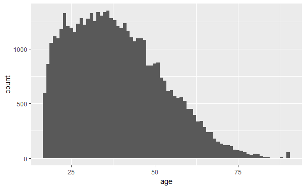

```r
  ggplot(records) + geom_histogram(aes(x = age), binwidth = 1)
```

**education_num**  
This distribution looks as expected

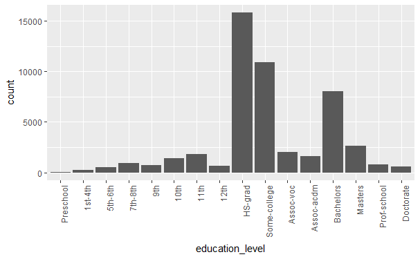

**capital_gain**

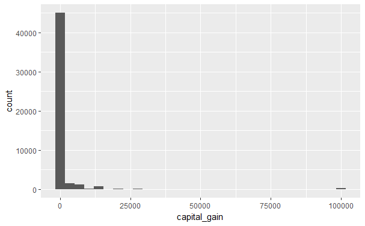

**capital_gain without 0**  
It is odd that $99,999 has such a high frequency count. I’m also wondering why there isn’t more variability here? I’m guessing most of the people in the united states aren’t actively selling assets or property.. which makes this distribution more sensible.

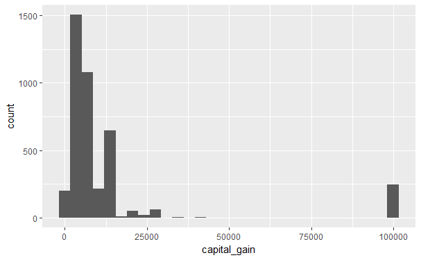

**capital_loss**  
This variable distribution looks as expected.

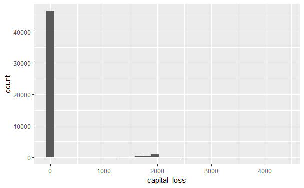

**capital_loss without 0**

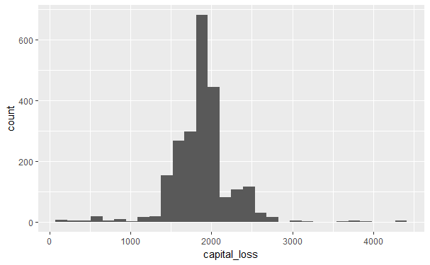

**hours_week**  
It is a little odd that there is a hard cutoff here at 100 hours. The distribution makes sense overall though.

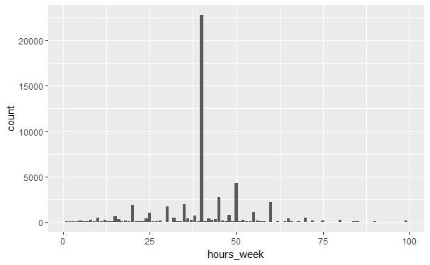

**hours_week without 40**

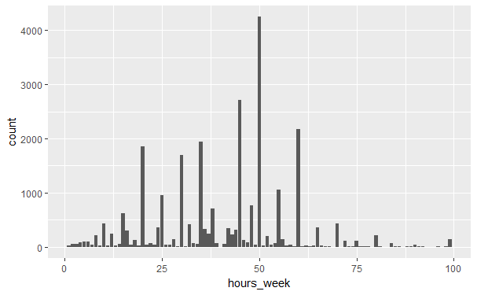

**over_50k**  
This distribution looks as expected

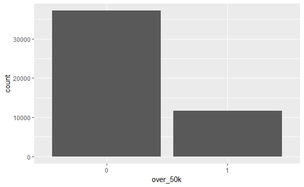

**country**  
This distribution looks as expected

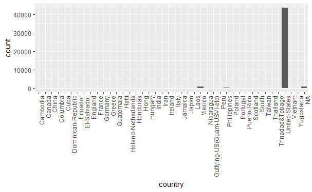

**Marital Status**  
The ‘never married’ proportion is suprisingly high. This must be because because the census is at the household level. The number of ‘married’ people should be double the frequency, but since only one spouse responds to the survey that number is halved.

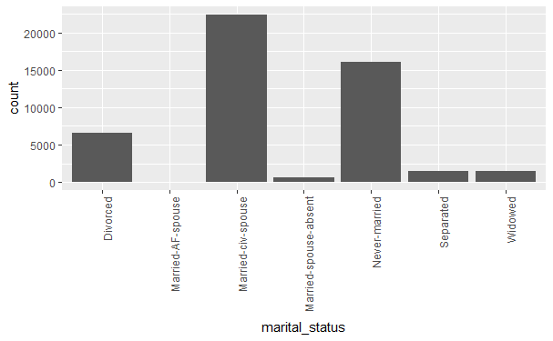

**Occupation**  
Distribution looks as expected here. Maybe the NA categories consists mainly of unemployed people

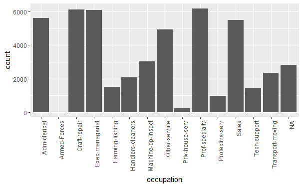

**race**  
I would have thought the proportion of other races would be higher here.

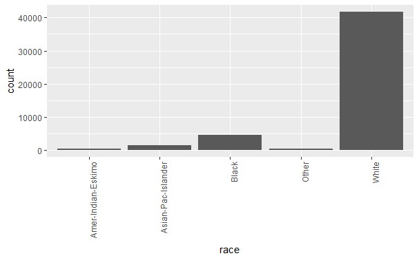

**relationship**  
Maybe the husband count is much higher than wife count because the males of each household are filling the census out.

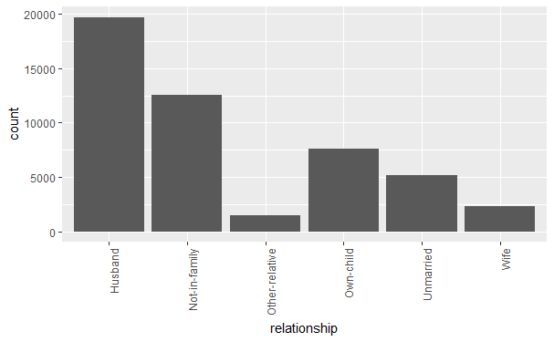

**sex**  
The gender difference here is not representative of the US population as a whole. Again, this can likely be occuring because the males of the houselholds are filling this out.

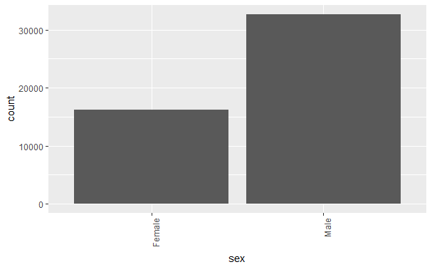

**workclass**

This distribution looks as expected

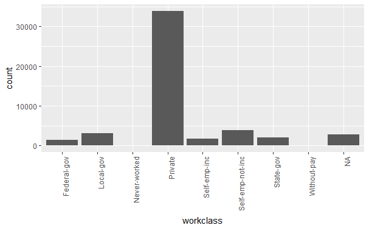

#### **Bi-Variate Plots**

In this section I create visualizations in order to better understand associations between variables.

**Age vs. Work Hours**  
I am a little surprised that the number of working hours doesn’t drop off more near age 75.

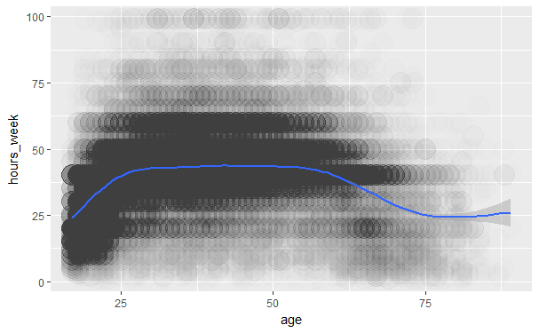

**Education vs. Work Hours**  
Interesting here that the higher education one has, the more they are working. I guess the opportunity cost is higher if you aren’t working with an advanced degree since the earning potential is much higher. It could also be that it is easier to get a job with a degree.

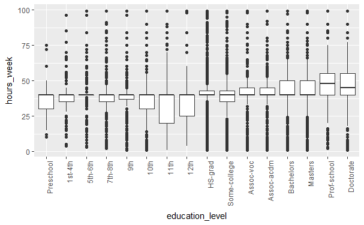

**Work Class vs. Work Hours**  
I thought federal and state government had strict 40 hour work weeks. It is weird that we are observing up to 100 hours in these sectors. It is odd that within the never worked category people are reporting working close to 25 hours a week on average.

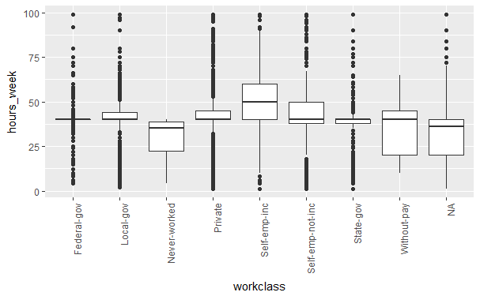

**Education Level vs. Marital Status**  
The pattern between marital status and education appears to be consistant

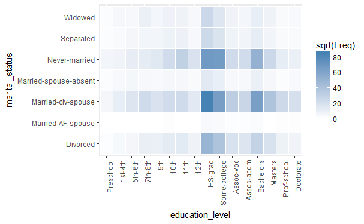

**Education Level vs. Capital Loss**

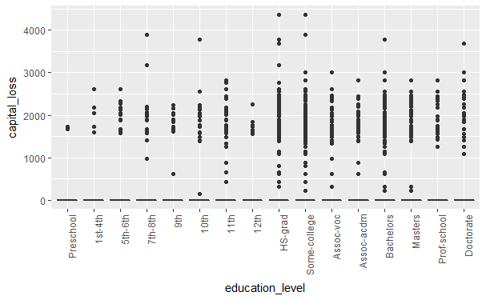

**Education Level vs. Capital Loss (Excluding 0)**  
Capital loss seems to be spread across education levels almost evenly

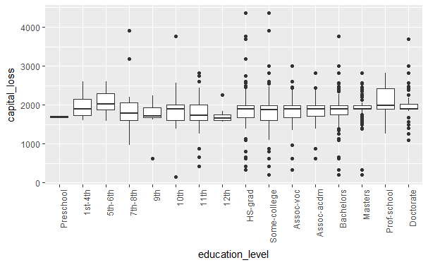

**Education vs. Capital Gain**

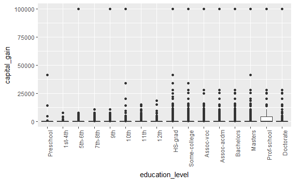

**Education vs. Capital Gain (Excluding 0)**  
As expected, the more education someone has, the more capital gains they are reporting

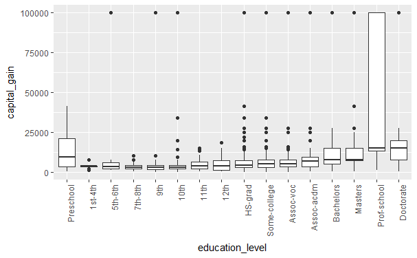

### Step 3: Split the data into training, validation, and test sets

```r
# set the random seed for reproducibility
set.seed(143)


# Create a vector with 1's 2's and 3's .
# each value has the proportion occurring that is desired
# for the training, validation, and test data splits.
n <- nrow(records)

split_number <-  c( rep(1, ceiling( n * 0.7) ),
                    rep(2, ceiling( n * 0.2) ),
                    rep(3, ceiling( n * 0.1) ) )

records$split_number  <- split_number[sample(1:n,n)] # assign random split


# save each split to a different object
records %>%
  filter(split_number == 1) -> train

records %>%
  filter(split_number == 2) -> valid

records %>%
  filter(split_number == 3) -> test


# write each to a csv
write.csv(train, 'C:/Users/Will/Documents/MSA/jobs/rti_challenge/data-scientist-exercise01/data/train.csv', row.names = F)
write.csv(valid, 'C:/Users/Will/Documents/MSA/jobs/rti_challenge/data-scientist-exercise01/data/valid.csv', row.names = F)
write.csv(test, 'C:/Users/Will/Documents/MSA/jobs/rti_challenge/data-scientist-exercise01/data/test.csv', row.names = F)
```